# Analyzing Multi-Party Turn-Taking Behavior

### James Trujillo ( james.trujillo@donders.ru.nl ) Wim Pouw ( wim.pouw@donders.ru.nl ) 18-11-2021

[figure not shown]

### Info documents

This module gives an introduction to analyzing the turn-taking behavior of a group of individuals. We'll use manual annotations of speech behavior, quantify the timing of turn transitions as gaps and overlaps between speakers, and look at some ways we can perform additional analyses using these data.  
**Packages:** * pympi * antropy  
**Note on automatic utterance extraction:** This module is partially based on the processing and analysis pipeline described in a previous publication (see below). The OSF project for this article also contains code for automatically extracting and processing single utterances from the audio stream. Note that this does require separate audio streams (e.g., from separate microphones) for each speaker. Code available at: https://osf.io/bvm56/?view_only=7165d0c25f9344a592685f4bae0c1bf7 * Trujillo J.P., Levinson S.C., Holler J. (2021) Visual Information in Computer-Mediated Interaction Matters: Investigating the Association Between the Availability of Gesture and Turn Transition Timing in Conversation. In: Kurosu M. (eds) Human-Computer Interaction. Design and User Experience Case Studies. HCII 2021. Lecture Notes in Computer Science, vol 12764. Springer, Cham. https://doi.org/10.1007/978-3-030-78468-3_44 Open Access link: https://pure.mpg.de/rest/items/item_3347812/component/file_3347813/content * Module citation: Trujillo, J.P. & Pouw, W.T.J.L. (2021-11-18). *Analyzing Multi-Party Turn-Taking Behavior* \[day you visited the site]. Retrieved from: https://github.com/WimPouw/EnvisionBootcamp2021/tree/main/Python/MediaBodyTracking

### Introduction

Turn-taking is a fundamental aspect of human communication, and takes place quite rapidly, with turn transitions (i.e., the time between one speaker's utterance ending and the next speaker's utterance beginning) often on the scale of ~200ms (Stivers et al., doi:10.1073pnas.0903616106%20pna/). This timing is important not only for fast-pace information exchange, but is socially meaningful, as longer-than-expected inter-speaker gaps can be interpreted as signalling a dispreferred response (Kendrick & Torreira 2015 doi: 10.1080/0163853X.2014.955997).  
Beyond theoretical interest, quantifying turn-taking behavior can be interesting for understanding group dynamics. One study suggests that smoother turn transitions (i.e., shorter gaps, shorter overlaps) are more associated with collaborative behaviors compared to conflict behaviors (Kim et al., 2015, INTERSPEECH). Similarly, Pincus & Guastello (2005; DOI: 10.1177/1046496405280864) used non-linear dynamics approaches to show that information theoretic patterns in turn-taking behavior correlate with self-report measures of group dynamics (e.g., leadership, conflict).

### Video Tutorial

```python
from IPython.display import HTML

HTML('<iframe width="936" height="527" src="https://www.youtube.com/embed/s-XV4GCSjtc?start=10437" title="YouTube video player" frameborder="0" allow="accelerometer; autoplay; clipboard-write; encrypted-media; gyroscope; picture-in-picture" allowfullscreen></iframe>')
```

[video not shown]

```python
from parselmouth.praat import call
import os
import pympi
from tabulate import tabulate
import numpy as np
import pandas as pd
import matplotlib.pyplot as plt
```

```python
def get_multispeaker_transitions(utterances_1, utterances_2, utterances_3):
    # set max distance between them to be 2s, then find the closest occurence in
    # second dataframe. Max distance is based on Heldner & Edlund 2010
    # output times are in ms

    speaker_count = 3
    if not utterances_1:
        speaker_count -=1
    if not utterances_2:
        speaker_count -=1
    if not utterances_3:
        speaker_count -=1

    if speaker_count < 2:
        trans_dur = np.nan
        gap_dur = np.nan
        utterance_time_trans = np.nan
        utterance_time_gap = np.nan
    else:
        trans_dur1, gap_dur1, utterance_time_trans1, utterance_time_gap1, overlap_dur1, utterance_time_overlap1,timestamp1 = get_gaps_overlaps(
          utterances_1, utterances_2, utterances_3)
        trans_dur2, gap_dur2, utterance_time_trans2, utterance_time_gap2, overlap_dur2, utterance_time_overlap2,timestamp2 = get_gaps_overlaps(
          utterances_2, utterances_1, utterances_3)
        trans_dur3, gap_dur3, utterance_time_trans3, utterance_time_gap3, overlap_dur3, utterance_time_overlap3,timestamp3 = get_gaps_overlaps(
          utterances_3, utterances_2, utterances_1)


        print("Turn Transition Statistics for Participant 1")
        get_turn_trans_stats(trans_dur1,gap_dur1, overlap_dur1)
        print("Turn Transition Statistics for Participant 2")
        get_turn_trans_stats(trans_dur2,gap_dur2, overlap_dur2)
        print("Turn Transition Statistics for Participant 3")
        get_turn_trans_stats(trans_dur3,gap_dur3, overlap_dur3)

        # these will be used in the dataframe to indicate which speaker we're talking about
        p1 = ["1"]*len(trans_dur1)
        p2 = ["2"]*len(trans_dur2)
        p3 = ["3"]*len(trans_dur3)

        participant = p1 + p2 + p3
        timestamp = timestamp1 + timestamp2 + timestamp3

        # now we need to stack the utterance data
        trans_dur = trans_dur1 + trans_dur2 + trans_dur3
        utterance_time_trans = utterance_time_trans1 + utterance_time_trans2 + utterance_time_trans3

        df = pd.DataFrame(np.column_stack([participant,timestamp,trans_dur, utterance_time_trans]),
                               columns=['participant', 'timestamp','transition_duration','utterance_duration']
                               )

        return df


def get_gaps_overlaps(utterances_1, utterances_2, utterances_3):
    # this gets the utterance and turn-transition speaker from the perspective of one speaker
    # It doesn't matter what order the second two are in, as we just care about the averages in
    # the end anyway
    trans_dur = []
    utterance_time_trans = []
    timestamp=[]

    for u_idx,u in enumerate(utterances_1):
        # here we want to get the difference between this utterance's offset (u[1]) and all onsets from the other two speakers
        diffs2 = [abs(u[1] - u2[0]) for u2 in utterances_2]
        diffs3 = [abs(u[1] - u3[0]) for u3 in utterances_3]

        min_dif2 = np.argmin(diffs2)
        min_dif3 = np.argmin(diffs3)

        # also get within-speaker differences
        # we get this to make sure our inter-speaker differences are less than this
        # otherwise, we may not be getting the turn transition from this utterance
        if u_idx < len(utterances_1)-1:
            min_pause = utterances_1[u_idx+1][0] - u[1]
        else:
            # if this is not the last utterance, we ignore this
            min_pause = min([diffs2[min_dif2],diffs3[min_dif3]]) +1
        # is there an utterance from p2 or p3 starting within 2s of this utterance from p1?

        if diffs2[min_dif2] < 2000 and diffs2[min_dif2] < min_pause:
            trans_dur.append(int(utterances_2[min_dif2][0] - u[1]))
            utterance_time_trans.append(int(utterances_1[u_idx][1] - utterances_1[u_idx][0]))
            timestamp.append(int(utterances_2[min_dif2][0]))
        if diffs3[min_dif3] < 2000 and diffs3[min_dif3] < min_pause:
            trans_dur.append(int(utterances_3[min_dif3][0] - u[1]))
            utterance_time_trans.append(int(utterances_1[u_idx][1] - utterances_1[u_idx][0]))
            timestamp.append(int(utterances_3[min_dif3][0]))

    # finally, we want to separate these values into gaps and overlaps
    gap_dur = []
    overlap_dur = []
    utterance_time_gap = []
    utterance_time_overlap = []
    for idx, val in enumerate(trans_dur):
        if val > 0:
            gap_dur.append(val)
            utterance_time_gap.append(int(utterance_time_trans[idx]))
        elif val <= 0:
            overlap_dur.append(val)
            utterance_time_overlap.append(int(utterance_time_trans[idx]))

    return trans_dur, gap_dur, utterance_time_trans, utterance_time_gap, overlap_dur, utterance_time_overlap,timestamp
```

This function just gets us some summary stats for the turn taking behavior

```python
def get_turn_trans_stats(transitions, gaps, overlaps):
    if transitions and not np.all(np.isnan(transitions)):
        Gap_freq = len(gaps)/len(transitions)
        Overlap_freq = len(overlaps)/len(transitions)
    else:
        Gap_freq = 0
        Overlap_freq = 0
    turn_data = [['turn transition mean', np.mean(transitions)],
                 ['turn transition SD', np.std(transitions)],
                 ['turn transition median',np.median(transitions)],
                 ['Gap mean', np.mean(gaps)],
                 ['Gap SD',np.std(gaps)],
                 ['Gap median',  np.median(gaps)],
                 ['Gap freq. (%)',Gap_freq],
                 ['Overlap mean', np.mean(overlaps)],
                 ['Overlap SD',np.std(overlaps)],
                 ['Overlap median',  np.median(overlaps)],
                 ['Overlap freq. (%)',Overlap_freq],]

    print(tabulate(turn_data, headers=['Stat','Value']))
```

```python
annot_dir = "./annotations/"

annotation_files = os.listdir(annot_dir)
eafob = pympi.Elan.Eaf(annot_dir + annotation_files[0])


utterances_1 = [annotation for annotation in eafob.get_annotation_data_for_tier("Participant1")]
utterances_2 = [annotation for annotation in eafob.get_annotation_data_for_tier("Participant2")]
utterances_3 = [annotation for annotation in eafob.get_annotation_data_for_tier("Participant3")]

df = get_multispeaker_transitions(utterances_1, utterances_2, utterances_3)
```

```
Turn Transition Statistics for Participant 1
Stat                          Value
----------------------  -----------
turn transition mean       4.25794
turn transition SD       667.521
turn transition median    25
Gap mean                 439.965
Gap SD                   439.934
Gap median               304.5
Gap freq. (%)              0.563492
Overlap mean            -558.2
Overlap SD               457.736
Overlap median          -494
Overlap freq. (%)          0.436508
Turn Transition Statistics for Participant 2
Stat                          Value
----------------------  -----------
turn transition mean      42.6245
turn transition SD       688.131
turn transition median    49
Gap mean                 435.401
Gap SD                   467.993
Gap median               249
Gap freq. (%)              0.601533
Overlap mean            -550.317
Overlap SD               522.741
Overlap median          -389
Overlap freq. (%)          0.398467
Turn Transition Statistics for Participant 3
Stat                          Value
----------------------  -----------
turn transition mean     -89.9789
turn transition SD       789.032
turn transition median    18
Gap mean                 457.444
Gap SD                   468.884
Gap median               332
Gap freq. (%)              0.523207
Overlap mean            -690.69
Overlap SD               612.205
Overlap median          -467
Overlap freq. (%)          0.476793
```

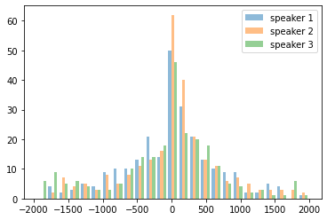

```python
df.transition_duration = pd.to_numeric(df.transition_duration, errors='coerce')

# plotting
tt_1 = df[df["participant"]=="1"]["transition_duration"]
tt_2 = df[df["participant"]=="2"]["transition_duration"]
tt_3 = df[df["participant"]=="3"]["transition_duration"]
plt.hist([tt_1,tt_2,tt_3],
         alpha=0.5, bins=25,
         label=["speaker 1","speaker 2","speaker 3"])
plt.legend(loc='upper right')
plt.show()
```

```python
import antropy as ant
```

```python
# first we need to sort this into a proper timeseries, disregarding individual IDs
df.timestamp = pd.to_numeric(df.timestamp, errors='coerce')
df.transition_duration = pd.to_numeric(df.transition_duration, errors='coerce')

sort_df = df.sort_values(by=["timestamp"], ascending=True)

sort_df.head()
```

|  | participant | timestamp | transition_duration | utterance_duration |
| --- | --- | --- | --- | --- |
| 0 | 1 | 10810 | 20 | 1310 |
| 89 | 2 | 11525 | 5 | 710 |
| 90 | 2 | 31950 | -100 | 990 |
| 91 | 2 | 41530 | 70 | 5960 |
| 1 | 1 | 42985 | 165 | 1290 |

```python
# Calculate Approximate entropy
print(ant.sample_entropy(sort_df["transition_duration"]))
```

```
2.199106045435925
```

Aside from the general entropy across the whole session, which we could compare across groups or correlate with personal or group characteristics, we can also look at the change in entropy over time. We'll split the session into 4 minute windows to assess entropy across the session.

For the analysis, we'll use the categorical data corresponding to the "transitioning speaker" and calculate Permutation Entropy. Permutation entropy captures the ordering of values in a time-series. In this case, we want the complexity with which the group switches from one speaker to the next. Is it always speaker 1 followed by speaker 2, and vice versa? This would be low entropy. Or do we see all possible orders; speaker 3, then 1, followed by 3 again, then 2.. The more unpredictable the switching, the higher the entropy.

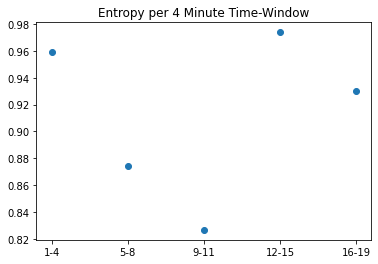

```python
tt_entropy = []

window_length = (1000*60)*4 #written out just to make the window length easily understandable

window_start = 0
window_end = window_length
while window_end < sort_df["timestamp"][len(sort_df)-1]   :
    # get data for this time window
    window = sort_df[(sort_df["timestamp"] >window_start)&(sort_df["timestamp"] <window_end)]
    # calculate permutation entropy
    tt_entropy.append(ant.perm_entropy(window["participant"], normalize=True))
    # shift the window forward
    window_start = window_end
    window_end += window_length

# now plot the entropy over time
plt.scatter(["1-4","5-8","9-11","12-15","16-19"],tt_entropy)
plt.title("Entropy per 4 Minute Time-Window")
plt.show()
```

These values can again be correlated with group level characteristics, or to momentary annotations regarding breakthroughs, changes in topic, etc.